# Eurovision Song Contest (1998-2010)

Regina Pogosian

May 18, 2018

## Required Tools

Before you begin, you will need to create a new RMarkdown file in RStudio with the following libraries:

- tidyverse
- tidyr
- dplyr
- reshape
- ggplot2

You will also need to Eurovision contest dataset, which you can find at: https://docs.google.com/spreadsheets/d/1vW06CKRtgUFzZ4WZEzh_OZEycuhMvUCCxJ6MtXmeBg4/edit?hl=en&hl=en#gid=3

You will need to make sure that you download the dataset as a csv file.

## 1. Getting Started

The first thing that you will need to do is to download the csv (comma-seperated values) file of the dataset from https://docs.google.com/spreadsheets/d/1vW06CKRtgUFzZ4WZEzh_OZEycuhMvUCCxJ6MtXmeBg4/edit?hl=en&hl=en#gid=3. The file that you will get will be called “Eurovision voting data 1998-2010 - All entries_ 1998-2010.csv”. We will need to load the file into RStudio so that we can work with it. When we load it in, it will be in the form of a table, which will allow us to see the data better and pull information from it.

Before we begin, we will load all of the libraries that we are going to use throughout this tutorial.

```r
library(tidyverse)
library(tidyr)
library(dplyr)
library(reshape)
library(ggplot2)
```

Now that we have loaded all of the necessary files, we are going to load in the dataset.

```r
eurovision_df <- read_csv("Eurovision voting data 1998-2010 - All entries_ 1998-2010.csv")
eurovision_df
```

```
## # A tibble: 316 x 64
##     Year Country  Region     `Song language` English Artist     Song
##    <int> <chr>    <chr>      <chr>           <chr>   <chr>      <chr>
##  1  2010 Germany  Western E… English         Yes     Lena Meye… "\"Satell…
##  2  2010 Turkey   Independe… English         Yes     maNga      "\"We Cou…
##  3  2010 Romania  Former So… English         Yes     Paula Sel… "\"Playin…
##  4  2010 Denmark  Scandinav… English         Yes     ChanÇe an… "\"In a M…
##  5  2010 Azerbai… Former So… English         Yes     Safura Al… "\"Drip D…
##  6  2010 Belgium  Western E… English         Yes     Tom Dice   "\"Me and…
##  7  2010 Armenia  Former So… English         Yes     Eva Rivas  "\"Aprico…
##  8  2010 Greece   Western E… Greek           No      Giorgos A… "\"OPA\""
##  9  2010 Georgia  Former So… English         Yes     Sopho Niz… "\"Shine\…
## 10  2010 Ukraine  Former So… English         Yes     Alyosha    "\"Sweet …
## # ... with 306 more rows, and 57 more variables: `English
## #   translation` <chr>, `Artist gender` <chr>, `Group/Solo` <chr>,
## #   Place <int>, Points <int>, `Host Country` <chr>, `Host region` <chr>,
## #   `Home/Away Country` <chr>, `Home/Away Region` <chr>, `Approximate
## #   Betting Prices` <int>, Albania <int>, Andorra <int>, Armenia <int>,
## #   Austria <int>, Azerbaijan <int>, Belarus <int>, Belgium <int>, `Bosnia
## #   and Herzegovina` <int>, Bulgaria <int>, Croatia <int>, Cyprus <int>,
## #   `Czech Republic` <int>, Denmark <int>, Estonia <int>, Finland <int>,
## #   France <int>, Georgia <int>, Germany <int>, Greece <int>,
## #   Hungary <int>, Iceland <int>, Ireland <int>, Israel <int>,
## #   Latvia <int>, Lithuania <int>, Macedonia <int>, Malta <int>,
## #   Moldova <int>, Monaco <int>, Montenegro <int>, Netherlands <int>,
## #   Norway <int>, Poland <int>, Portugal <int>, Romania <int>,
## #   Russia <int>, `San Marino` <int>, Serbia <int>, `Serbia &
## #   Montenegro` <int>, Slovakia <int>, Slovenia <int>, Spain <int>,
## #   Sweden <int>, Switzerland <int>, Turkey <int>, Ukraine <int>, `United
## #   Kingdom` <int>
```

### 1.1 Looking at our data

Now we have a data frame called eurovision_df. In the data frame, we can see the year of the Eurovision competition, the country that participated along with what region it is from, the language the song was sung in, whether or not it was in English, the name of the artist representing the country, the song they sang, if there is an English translation of the song, the gender of the artist, wherter or not it was a group or a solo performance, what place they received, the total number of points they received, the country in which the competition was hosted in, the region the competition was hosted in, whether it was home country or away, whether is was a home region or away, the approximate betting prices, and then a breakdown of how many points each of the countries gave that country. Any missing data has an NA.

### 1.2 Tidying our data

The data that we have includes everything about each of the countries and the songs and artists that represented that country. In order to determine if a certain country votes for one more than the other, we don’t need to know the other information about the country so we can remove them from the table. With the dplyr library that we installed earlier, we can use the select function and deselect everything that we do not want in out table. The following code fragment does that for us.

If you want to learn more about the dpylr library, you can read more about it here: https://www.r-project.org/nosvn/pandoc/dplyr.html

```r
eurovision <- select(eurovision_df, -Year, -Region, -Song, -English, -Artist, -`Song language`, -`Artist gender`, -`English translation`, -`Group/Solo`, -`Host Country`, -`Host region`, -`Home/Away Country`, -`Home/Away Region`, -`Approximate Betting Prices`, -Place, -Points)
eurovision
```

```
## # A tibble: 316 x 48
##    Country    Albania Andorra Armenia Austria Azerbaijan Belarus Belgium
##    <chr>        <int>   <int>   <int>   <int>      <int>   <int>   <int>
##  1 Germany         10      NA       0      NA          1       0      10
##  2 Turkey           8      NA       0      NA         12       3       6
##  3 Romania          5      NA       1      NA          7       1       0
##  4 Denmark          2      NA       5      NA          4       0       2
##  5 Azerbaijan       0      NA       0      NA          0       6       5
##  6 Belgium          0      NA       0      NA          0       0       0
##  7 Armenia          0      NA       0      NA          0       5       7
##  8 Greece          12      NA       3      NA          0       0      12
##  9 Georgia          0      NA      12      NA          8       7       4
## 10 Ukraine          0      NA       8      NA         10      10       0
## # ... with 306 more rows, and 40 more variables: `Bosnia and
## #   Herzegovina` <int>, Bulgaria <int>, Croatia <int>, Cyprus <int>,
## #   `Czech Republic` <int>, Denmark <int>, Estonia <int>, Finland <int>,
## #   France <int>, Georgia <int>, Germany <int>, Greece <int>,
## #   Hungary <int>, Iceland <int>, Ireland <int>, Israel <int>,
## #   Latvia <int>, Lithuania <int>, Macedonia <int>, Malta <int>,
## #   Moldova <int>, Monaco <int>, Montenegro <int>, Netherlands <int>,
## #   Norway <int>, Poland <int>, Portugal <int>, Romania <int>,
## #   Russia <int>, `San Marino` <int>, Serbia <int>, `Serbia &
## #   Montenegro` <int>, Slovakia <int>, Slovenia <int>, Spain <int>,
## #   Sweden <int>, Switzerland <int>, Turkey <int>, Ukraine <int>, `United
## #   Kingdom` <int>
```

Once we have taken out all of the attributes that we do not need, we are left with the each country and how many points they received from other countries. One thing we should notice right away is that there are some places where there is missing data and it is represented with NA. We are going to leave the NA in the data so that, when we look at the average minimum number of points, whatever number we put in there does not interfere with our data. If we replace the NA with zero, that would affect our data and give us wrong results.

The reason that there are NA in the table is due to the fact that some years, some countries did not participate in the competition so there is no data on who they voted for.

The data, in the form that it was given to us is tidy, meaning that thee attributes forms a column, each entity forms a row, and the type of entity forms the table.

If you want to learn more about tidy data, you can watch more about it here: https://www.lynda.com/R-tutorials/What-tidy-data/594442/645365-4.html

## 2. Exploratory Data Analysis

Now that we have tidied up the data and took out the data that we do not need, we can start to do some exploratory data analysis on it. We will do this by making a visual representation of the data so we can better see it. In addition to doing visual analysis, we will also do statistical anaylsis on the data.

### 2.1 Looking at Votes between Countries

The first thing we are going to do before we begin to analize our data, we are going to get the mean points that each of the countries gave each other. We will do so by using the aggregate function.

If you would like to learn more about aggregate, this website has a lot of good information about it: https://www.rdocumentation.org/packages/stats/versions/3.5.0/topics/aggregate

```r
options(warn = -1)
euro_mean <- aggregate(x=eurovision, list(eurovision$Country), mean)
euro_mean[1:10,]
```

```
##                   Group.1 Country  Albania Andorra   Armenia Austria
## 1                 Albania      NA       NA      NA        NA      NA
## 2                 Armenia      NA 0.400000      NA        NA      NA
## 3                 Austria      NA       NA      NA        NA      NA
## 4              Azerbaijan      NA 1.333333      NA 0.3333333      NA
## 5                 Belarus      NA 1.000000      NA 5.0000000      NA
## 6                 Belgium      NA       NA      NA        NA      NA
## 7  Bosnia and Herzegovina      NA       NA      NA        NA      NA
## 8                Bulgaria      NA 0.000000       0 4.0000000       6
## 9                 Croatia      NA       NA      NA        NA      NA
## 10                 Cyprus      NA       NA      NA        NA      NA
##    Azerbaijan Belarus Belgium Bosnia and Herzegovina Bulgaria    Croatia
## 1          NA     0.0   0.800               3.000000       NA  5.2000000
## 2          NA     5.2   9.600               1.200000 7.600000  0.0000000
## 3          NA      NA   2.600                     NA       NA  1.0000000
```

[output cut: 73 more lines]

From the table that we got, it took all of the countries and put them into a new column called ‘Group.1’ and then left the ‘Country’ column empty. We are going to fix that by removing the Country column and renaming ‘Group.1’ to ‘Country’ like so:

```r
euro_mean <- select(euro_mean, -Country)
colnames(euro_mean)[names(euro_mean) == 'Group.1'] <- 'Country'
euro_mean[1:10,]
```

```
##                   Country  Albania Andorra   Armenia Austria Azerbaijan
## 1                 Albania       NA      NA        NA      NA         NA
## 2                 Armenia 0.400000      NA        NA      NA         NA
## 3                 Austria       NA      NA        NA      NA         NA
## 4              Azerbaijan 1.333333      NA 0.3333333      NA         NA
## 5                 Belarus 1.000000      NA 5.0000000      NA         NA
## 6                 Belgium       NA      NA        NA      NA         NA
## 7  Bosnia and Herzegovina       NA      NA        NA      NA         NA
## 8                Bulgaria 0.000000       0 4.0000000       6         NA
## 9                 Croatia       NA      NA        NA      NA         NA
## 10                 Cyprus       NA      NA        NA      NA         NA
##    Belarus Belgium Bosnia and Herzegovina Bulgaria    Croatia    Cyprus
## 1      0.0   0.800               3.000000       NA  5.2000000  0.000000
## 2      5.2   9.600               1.200000 7.600000  0.0000000  7.800000
## 3       NA   2.600                     NA       NA  1.0000000  1.200000
```

[output cut: 73 more lines]

Now that we have the mean votes from each country and we have the data looking the way we want it to, we can now start to put it in a form in which we can more easily visualize the data. To visualize the data, we are going to create a plot that shows the average points that the countries gave to other competing countries in the competition.

To plot the data, we are going to use ggplot to help us. If you want to experiment more with it, you may find this link useful: https://tutorials.iq.harvard.edu/R/Rgraphics/Rgraphics.html

This is also a nice ggplot cheatsheet: https://www.rstudio.com/wp-content/uploads/2015/03/ggplot2-cheatsheet.pdf

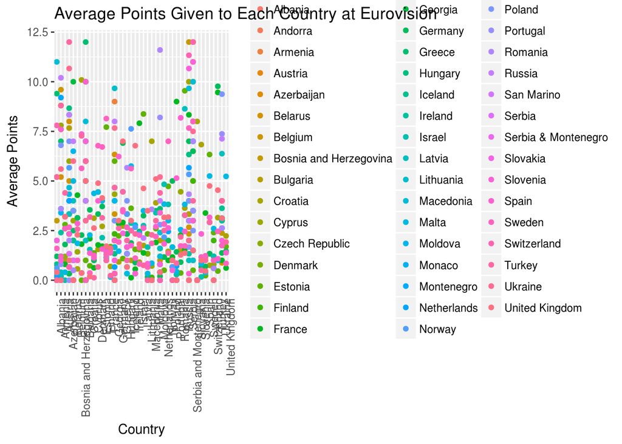

```r
euro_mean %>% tidyr::gather("countries", "Average Points", 2:48) %>%
  ggplot(aes(x=Country, y=`Average Points`)) +
  geom_point(aes(colour=countries)) +
  theme(axis.text.x = element_text(angle=90, hjust=1)) +
  labs(title = "Average Points Given to Each Country at Eurovision")
```

This is how we determine the countries that gave the most points to other countries.

First we get the table with each of the competing countries and then find the country that gave them the most points.

```r
options(warn = -1)
euro_max <- cbind(euro_mean,do.call(rbind,apply(euro_mean,1,function(x) {data.frame(max=max(x), max.col.name=names(euro_mean)[which.max(x)],stringsAsFactors=FALSE)})))
colnames(euro_max)[names(euro_max) == 'max.col.name'] <- 'Max Country'
euro_max <- select(euro_max, -Albania, -Andorra, -Armenia, -Austria, -Azerbaijan, -Belarus, -Belgium, -`Bosnia and Herzegovina`, -Bulgaria, -Croatia, -Cyprus, -`Czech Republic`, -Denmark, -Estonia, -Finland, -France, -Georgia, -Germany, -Greece, -Hungary, -Iceland, -Ireland, -Israel, -Latvia, -Lithuania, -Macedonia, -Malta, -Moldova, -Monaco, -Montenegro, -Netherlands, -Norway, -Poland, -Portugal, -Romania, -Russia, -`San Marino`, -Serbia, -`Serbia & Montenegro`, -Slovakia, -Slovenia, -Spain, -Sweden, -Switzerland, -Turkey, -Ukraine, -`United Kingdom`, -max)
euro_max
```

```
##                   Country            Max Country
## 1                 Albania              Macedonia
## 2                 Armenia                 Russia
## 3                 Austria                 Turkey
## 4              Azerbaijan                 Turkey
## 5                 Belarus                Georgia
## 6                 Belgium                 France
## 7  Bosnia and Herzegovina                Croatia
## 8                Bulgaria                 Greece
## 9                 Croatia                Germany
## 10                 Cyprus                  Malta
## 11                Denmark                 Sweden
## 12                Estonia                 Sweden
## 13                Finland                 Sweden
## 14                 France                Estonia
```

[output cut: 28 more lines]

```r
options(warn = -1)
euro_min <- cbind(euro_mean,do.call(rbind,apply(euro_mean,1,function(x) {data.frame(min=min(x[x > 1]), min.col.name=names(euro_mean)[which.min(x)],stringsAsFactors=FALSE)})))
colnames(euro_min)[names(euro_min) == 'min.col.name'] <- 'Min Country'
euro_min <- select(euro_min, -Albania, -Andorra, -Armenia, -Austria, -Azerbaijan, -Belarus, -Belgium, -`Bosnia and Herzegovina`, -Bulgaria, -Croatia, -Cyprus, -`Czech Republic`, -Denmark, -Estonia, -Finland, -France, -Georgia, -Germany, -Greece, -Hungary, -Iceland, -Ireland, -Israel, -Latvia, -Lithuania, -Macedonia, -Malta, -Moldova, -Monaco, -Montenegro, -Netherlands, -Norway, -Poland, -Portugal, -Romania, -Russia, -`San Marino`, -Serbia, -`Serbia & Montenegro`, -Slovakia, -Slovenia, -Spain, -Sweden, -Switzerland, -Turkey, -Ukraine, -`United Kingdom`, -min)
euro_min
```

```
##                   Country    Min Country
## 1                 Albania        Belarus
## 2                 Armenia        Croatia
## 3                 Austria         Israel
## 4              Azerbaijan       Portugal
## 5                 Belarus        Belgium
## 6                 Belgium        Croatia
## 7  Bosnia and Herzegovina        Estonia
## 8                Bulgaria        Albania
## 9                 Croatia United Kingdom
## 10                 Cyprus         Turkey
## 11                Denmark         Turkey
## 12                Estonia          Spain
## 13                Finland         Israel
## 14                 France          Malta
```

[output cut: 28 more lines]

We can now use ggplot to graph the max from the data that we gathered above.

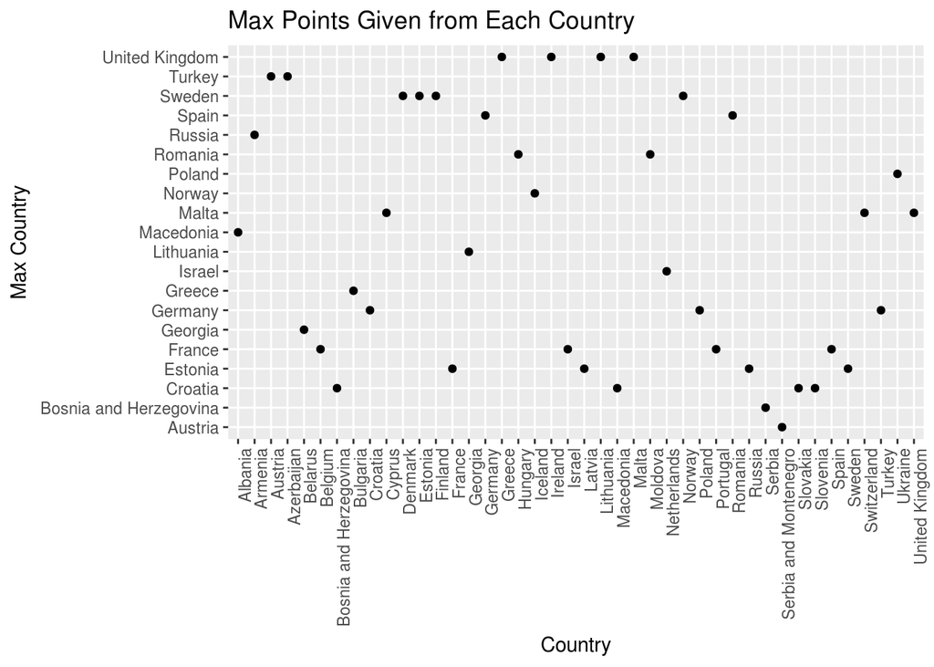

```r
euro_max %>%
  ggplot(aes(x=Country, y=`Max Country`)) +
  geom_point() +
  theme(axis.text.x = element_text(angle=90, hjust=1)) +
  labs(title = "Max Points Given from Each Country")
```

We can now use ggplot to graph the min from the data that we gathered above.

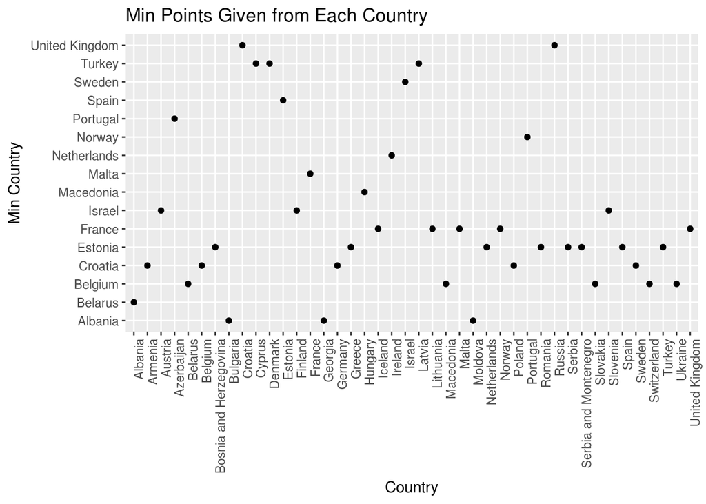

```r
euro_min %>%
  ggplot(aes(x=Country, y=`Min Country`)) +
  geom_point() +
  theme(axis.text.x = element_text(angle=90, hjust=1)) +
  labs(title = "Min Points Given from Each Country")
```

We were able to use the statistical anaylsis (finding the mean number of points that the countries gave) to create a visual representation of the data in the form of a plot. We made two plots to be able to see one graph of the max points and anothe graph with the min points.

### 2.2 Looking at Votes between Countries and their Regions

We looked at what countries gave more or less points to which countries and we could see some interesting things. Another thing that we can look at which can help us see if there is any relationship between them, is the regions and how the voting is distributed there.

Lets bring back the data that we had in the beginning so that we can get the data that we want.

This is the same data that we had in the beginning:

```r
eurovision_df
```

```
## # A tibble: 316 x 64
##     Year Country  Region     `Song language` English Artist     Song
##    <int> <chr>    <chr>      <chr>           <chr>   <chr>      <chr>
##  1  2010 Germany  Western E… English         Yes     Lena Meye… "\"Satell…
##  2  2010 Turkey   Independe… English         Yes     maNga      "\"We Cou…
##  3  2010 Romania  Former So… English         Yes     Paula Sel… "\"Playin…
##  4  2010 Denmark  Scandinav… English         Yes     ChanÇe an… "\"In a M…
##  5  2010 Azerbai… Former So… English         Yes     Safura Al… "\"Drip D…
##  6  2010 Belgium  Western E… English         Yes     Tom Dice   "\"Me and…
##  7  2010 Armenia  Former So… English         Yes     Eva Rivas  "\"Aprico…
##  8  2010 Greece   Western E… Greek           No      Giorgos A… "\"OPA\""
##  9  2010 Georgia  Former So… English         Yes     Sopho Niz… "\"Shine\…
## 10  2010 Ukraine  Former So… English         Yes     Alyosha    "\"Sweet …
## # ... with 306 more rows, and 57 more variables: `English
## #   translation` <chr>, `Artist gender` <chr>, `Group/Solo` <chr>,
## #   Place <int>, Points <int>, `Host Country` <chr>, `Host region` <chr>,
## #   `Home/Away Country` <chr>, `Home/Away Region` <chr>, `Approximate
## #   Betting Prices` <int>, Albania <int>, Andorra <int>, Armenia <int>,
## #   Austria <int>, Azerbaijan <int>, Belarus <int>, Belgium <int>, `Bosnia
## #   and Herzegovina` <int>, Bulgaria <int>, Croatia <int>, Cyprus <int>,
## #   `Czech Republic` <int>, Denmark <int>, Estonia <int>, Finland <int>,
## #   France <int>, Georgia <int>, Germany <int>, Greece <int>,
## #   Hungary <int>, Iceland <int>, Ireland <int>, Israel <int>,
## #   Latvia <int>, Lithuania <int>, Macedonia <int>, Malta <int>,
## #   Moldova <int>, Monaco <int>, Montenegro <int>, Netherlands <int>,
## #   Norway <int>, Poland <int>, Portugal <int>, Romania <int>,
## #   Russia <int>, `San Marino` <int>, Serbia <int>, `Serbia &
## #   Montenegro` <int>, Slovakia <int>, Slovenia <int>, Spain <int>,
## #   Sweden <int>, Switzerland <int>, Turkey <int>, Ukraine <int>, `United
## #   Kingdom` <int>
```

Now, like before, lets get rid of the data that we don’t need and keep what we do. We are going to remove most of the data that we did before except this time, instead of getting rid of the “Region” column, we are going to get rid of the “Country” column.

We also want to make sure that we put in a zero anywhere where there is an NA. If we do not do that, then when we combine the regions to give the mean points from each region, then we will get NA for everthing.

```r
eurovision_region <- select(eurovision_df, -Year, -Country, -Song, -English, -Artist, -`Song language`, -`Artist gender`, -`English translation`, -`Group/Solo`, -`Host Country`, -`Host region`, -`Home/Away Country`, -`Home/Away Region`, -`Approximate Betting Prices`, -Place, -Points)
eurovision_region[is.na(eurovision_region)] <- 0
eurovision_region
```

```
## # A tibble: 316 x 48
##    Region       Albania Andorra Armenia Austria Azerbaijan Belarus Belgium
##    <chr>          <dbl>   <dbl>   <dbl>   <dbl>      <dbl>   <dbl>   <dbl>
##  1 Western Eur…   10.0        0    0          0       1.00    0      10.0
##  2 Independent     8.00       0    0          0      12.0     3.00    6.00
##  3 Former Soci…    5.00       0    1.00       0       7.00    1.00    0
##  4 Scandinavia     2.00       0    5.00       0       4.00    0       2.00
##  5 Former Soci…    0          0    0          0       0       6.00    5.00
##  6 Western Eur…    0          0    0          0       0       0       0
##  7 Former Soci…    0          0    0          0       0       5.00    7.00
##  8 Western Eur…   12.0        0    3.00       0       0       0      12.0
##  9 Former Soci…    0          0   12.0        0       8.00    7.00    4.00
## 10 Former Soci…    0          0    8.00       0      10.0    10.0     0
## # ... with 306 more rows, and 40 more variables: `Bosnia and
## #   Herzegovina` <dbl>, Bulgaria <dbl>, Croatia <dbl>, Cyprus <dbl>,
## #   `Czech Republic` <dbl>, Denmark <dbl>, Estonia <dbl>, Finland <dbl>,
## #   France <dbl>, Georgia <dbl>, Germany <dbl>, Greece <dbl>,
## #   Hungary <dbl>, Iceland <dbl>, Ireland <dbl>, Israel <dbl>,
## #   Latvia <dbl>, Lithuania <dbl>, Macedonia <dbl>, Malta <dbl>,
## #   Moldova <dbl>, Monaco <dbl>, Montenegro <dbl>, Netherlands <dbl>,
## #   Norway <dbl>, Poland <dbl>, Portugal <dbl>, Romania <dbl>,
## #   Russia <dbl>, `San Marino` <dbl>, Serbia <dbl>, `Serbia &
## #   Montenegro` <dbl>, Slovakia <dbl>, Slovenia <dbl>, Spain <dbl>,
## #   Sweden <dbl>, Switzerland <dbl>, Turkey <dbl>, Ukraine <dbl>, `United
## #   Kingdom` <dbl>
```

Now that we have the data for the regions, we can combine the rows and get the average points that they received so that we can then plot it.

```r
options(warn = -1)
euro_reg_mean <- aggregate(x=eurovision_region, list(eurovision_region$Region), mean)
euro_reg_mean
```

```
##                 Group.1 Region   Albania   Andorra   Armenia   Austria
## 1 Former Socialist Bloc     NA 0.4823529 1.3176471 1.6588235 1.1529412
## 2     Former Yugoslavia     NA 2.1750000 0.0500000 0.6250000 3.1500000
## 3           Independent     NA 1.6607143 0.5714286 0.3571429 1.1785714
## 4           Scandinavia     NA 0.8888889 1.4888889 0.7555556 0.7333333
## 5        Western Europe     NA 1.5888889 1.5222222 0.7666667 0.9222222
##   Azerbaijan   Belarus  Belgium Bosnia and Herzegovina  Bulgaria  Croatia
## 1 1.03529412 2.9058824 2.129412               1.505882 1.6352941 2.270588
## 2 0.30000000 0.7750000 0.775000               4.875000 1.2500000 6.375000
## 3 0.89285714 0.7321429 2.571429               1.892857 1.1071429 2.125000
## 4 0.37777778 0.9555556 2.044444               1.288889 0.3777778 1.266667
## 5 0.07777778 0.4666667 2.844444               1.677778 0.8888889 1.466667
##     Cyprus Czech Republic  Denmark  Estonia  Finland   France   Georgia
## 1 2.941176      1.3764706 1.517647 3.211765 2.023529 1.623529 1.4352941
## 2 1.425000      0.6000000 1.475000 0.350000 1.500000 2.275000 0.2000000
```

[output cut: 33 more lines]

Now that we got the the table, we need to clean it up a little bit. We can rename the column “Group.1” to “Region” and remove the “Region” column that is populated with NA. We can easily do that like so:

```r
euro_reg_mean <- select(euro_reg_mean, -Region)
colnames(euro_reg_mean)[names(euro_reg_mean) == 'Group.1'] <- "Regions"
euro_reg_mean
```

```
##                 Regions   Albania   Andorra   Armenia   Austria Azerbaijan
## 1 Former Socialist Bloc 0.4823529 1.3176471 1.6588235 1.1529412 1.03529412
## 2     Former Yugoslavia 2.1750000 0.0500000 0.6250000 3.1500000 0.30000000
## 3           Independent 1.6607143 0.5714286 0.3571429 1.1785714 0.89285714
## 4           Scandinavia 0.8888889 1.4888889 0.7555556 0.7333333 0.37777778
## 5        Western Europe 1.5888889 1.5222222 0.7666667 0.9222222 0.07777778
##     Belarus  Belgium Bosnia and Herzegovina  Bulgaria  Croatia   Cyprus
## 1 2.9058824 2.129412               1.505882 1.6352941 2.270588 2.941176
## 2 0.7750000 0.775000               4.875000 1.2500000 6.375000 1.425000
## 3 0.7321429 2.571429               1.892857 1.1071429 2.125000 1.660714
## 4 0.9555556 2.044444               1.288889 0.3777778 1.266667 1.888889
## 5 0.4666667 2.844444               1.677778 0.8888889 1.466667 2.455556
##   Czech Republic  Denmark  Estonia  Finland   France   Georgia  Germany
## 1      1.3764706 1.517647 3.211765 2.023529 1.623529 1.4352941 2.082353
## 2      0.6000000 1.475000 0.350000 1.500000 2.275000 0.2000000 2.550000
```

[output cut: 33 more lines]

Now that we cleaned up the table, we want to tidy our data. That means that we want each of the countries to be the entities and the regions to be the attributes. We an do this my transposing the table and then casting it to be a dataframe by using data.frame.

```r
euro_reg_mean <- data.frame(t(euro_reg_mean))
euro_reg_mean
```

```
##                                           X1                X2          X3
## Regions                Former Socialist Bloc Former Yugoslavia Independent
## Albania                            0.4823529         2.1750000   1.6607143
## Andorra                            1.3176471         0.0500000   0.5714286
## Armenia                            1.6588235         0.6250000   0.3571429
## Austria                            1.1529412         3.1500000   1.1785714
## Azerbaijan                        1.03529412        0.30000000  0.89285714
## Belarus                            2.9058824         0.7750000   0.7321429
## Belgium                             2.129412          0.775000    2.571429
## Bosnia and Herzegovina              1.505882          4.875000    1.892857
## Bulgaria                           1.6352941         1.2500000   1.1071429
## Croatia                             2.270588          6.375000    2.125000
## Cyprus                              2.941176          1.425000    1.660714
## Czech Republic                     1.3764706         0.6000000   0.1964286
## Denmark                             1.517647          1.475000    1.553571
## Estonia                             3.211765          0.350000    1.553571
## Finland                             2.023529          1.500000    1.714286
## France                              1.623529          2.275000    4.071429
## Georgia                            1.4352941         0.2000000   0.4107143
## Germany                             2.082353          2.550000    3.375000
## Greece                             3.3058824         1.2750000   2.5535714
## Hungary                            1.5411765         0.7000000   0.7142857
## Iceland                            2.0000000         0.9000000   0.6071429
## Ireland                             2.917647          1.025000    1.553571
## Israel                             3.4235294         0.7500000   0.8214286
## Latvia                              3.458824          0.625000    0.750000
## Lithuania                           3.400000          0.825000    1.071429
## Macedonia                          2.3411765         4.0000000   2.0000000
## Malta                               2.482353          1.375000    2.982143
## Moldova                            3.0117647         0.3500000   0.2678571
## Monaco                             0.3411765         0.8750000   0.5714286
## Montenegro                         0.6117647         2.0250000   0.2321429
## Netherlands                         1.811765          1.975000    2.660714
## Norway                              1.694118          2.100000    1.732143
## Poland                              3.129412          1.275000    1.053571
## Portugal                            2.423529          0.700000    1.339286
## Romania                             2.388235          1.950000    2.517857
## Russia                             3.4235294         1.5500000   0.9464286
## San Marino                         0.1411765         0.0000000   0.3571429
## Serbia                             0.8470588         1.6750000   0.3214286
```

[output cut: 43 more lines]

```
## Poland                    2.844444       1.488889
## Portugal                  2.177778       2.488889
## Romania                   1.555556       1.622222
## Russia                   1.3555556      1.9000000
## San Marino               0.2000000      0.1888889
## Serbia                   0.3777778      0.6444444
## Serbia & Montenegro      0.3111111      0.2777778
## Slovakia                 0.5777778      0.6222222
## Slovenia                  2.488889       1.411111
## Spain                     2.822222       2.766667
## Sweden                    5.066667       1.800000
## Switzerland              0.8444444      2.4333333
## Turkey                    1.844444       2.111111
## Ukraine                  1.4000000      0.6111111
## United Kingdom            3.822222       2.722222
```

Once we have transposed the table, the column names are X1, X2, X3, X4, and X5. Instead of that, we want the column names to be that of the region. In this step, we are going to rename the columns and remove the Regions row because we don’t need that in there.

```r
euro_reg_mean <- setNames(cbind(rownames(euro_reg_mean), euro_reg_mean, row.names = NULL),
         c("Countries", "Former Socialist Bloc", "Former Yugoslavia", "Independent", "Scandinavia", "Western Europe"))
euro_reg_mean <- euro_reg_mean[!row.names(euro_reg_mean)%in%"1",]
euro_reg_mean[1] <- lapply(euro_reg_mean[1], as.character)
euro_reg_mean[2] <- lapply(euro_reg_mean[2], as.double)
euro_reg_mean[3] <- lapply(euro_reg_mean[3], as.double)
euro_reg_mean[4] <- lapply(euro_reg_mean[4], as.double)
euro_reg_mean[5] <- lapply(euro_reg_mean[5], as.double)
euro_reg_mean[6] <- lapply(euro_reg_mean[6], as.double)
euro_reg_mean
```

```
##                 Countries Former Socialist Bloc Former Yugoslavia
## 2                 Albania                     4                37
## 3                 Andorra                    11                 2
## 4                 Armenia                    19                11
## 5                 Austria                    10                41
## 6              Azerbaijan                     9                 4
## 7                 Belarus                    34                16
## 8                 Belgium                    28                15
## 9  Bosnia and Herzegovina                    14                45
## 10               Bulgaria                    18                22
## 11                Croatia                    29                46
## 12                 Cyprus                    36                27
## 13         Czech Republic                    12                 9
## 14                Denmark                    15                28
## 15                Estonia                    40                 5
```

[output cut: 81 more lines]

Lets go ahead and plot this and see what we have.

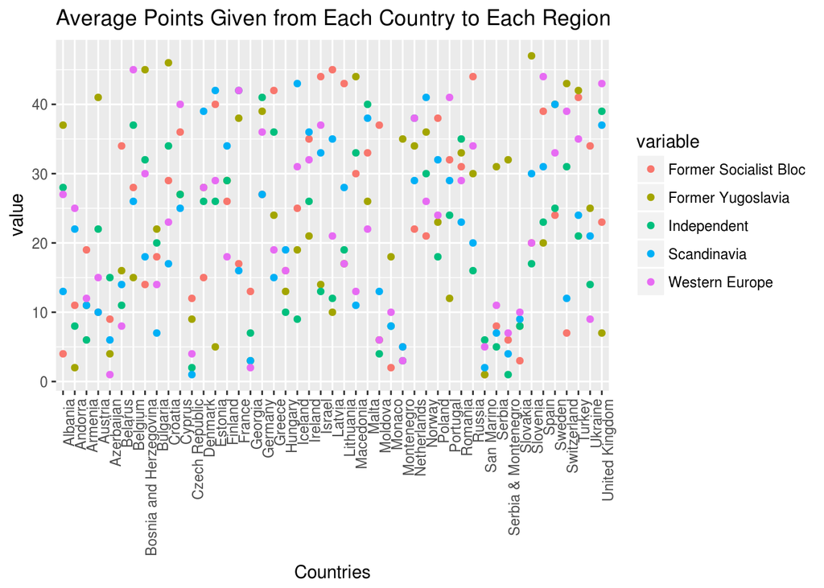

```r
euro.long <- melt(euro_reg_mean, id="Countries", measure = c("Former Socialist Bloc","Former Yugoslavia", "Independent", "Scandinavia", "Western Europe"))
ggplot(euro.long, aes(x=Countries, y=value, colour=variable)) +
  geom_point() +
  theme(axis.text.x = element_text(angle=90, hjust=1)) +
  labs(title = "Average Points Given from Each Country to Each Region")
```

```r
options(warn = -1)
euro_reg_max <- apply(euro_reg_mean,2, function(x) rownames(euro_reg_mean)[which.max(x)])
euro_reg_max <- rownames(euro_reg_mean[apply(euro_reg_mean, 2, max), ])
euro_reg_max <- cbind(euro_reg_mean,do.call(rbind,apply(euro_reg_mean,1,function(x) {data.frame(max=max(x), max.col.name=names(euro_reg_mean)[which.max(x)],stringsAsFactors=FALSE)})))
colnames(euro_reg_max)[names(euro_reg_max) == 'max.col.name'] <- 'Max Region'
euro_reg_max <- select(euro_reg_max, -`Former Socialist Bloc`, -`Former Yugoslavia`, -Independent, -Scandinavia, -`Western Europe`, -max)
euro_reg_max
```

```
##                 Countries            Max Region
## 2                 Albania     Former Yugoslavia
## 3                 Andorra        Western Europe
## 4                 Armenia Former Socialist Bloc
## 5                 Austria     Former Yugoslavia
## 6              Azerbaijan           Independent
## 7                 Belarus Former Socialist Bloc
## 8                 Belgium        Western Europe
## 9  Bosnia and Herzegovina     Former Yugoslavia
## 10               Bulgaria     Former Yugoslavia
## 11                Croatia     Former Yugoslavia
## 12                 Cyprus        Western Europe
## 13         Czech Republic Former Socialist Bloc
## 14                Denmark           Scandinavia
## 15                Estonia           Scandinavia
```

[output cut: 33 more lines]

Now let’s plot it:

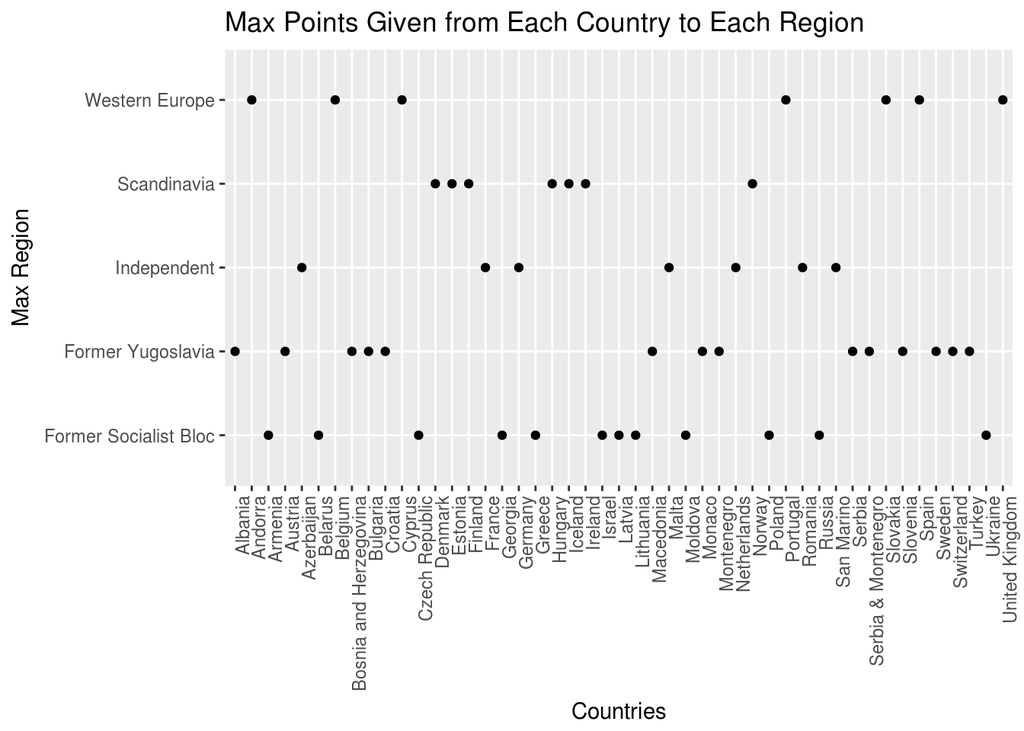

```r
euro_reg_max %>%
  ggplot(aes(x=Countries,y=`Max Region`)) +
  geom_point() +
  theme(axis.text.x = element_text(angle=90, hjust=1)) +
  labs(title = "Max Points Given from Each Country to Each Region")
```

```r
options(warn = -1)
euro_reg_min <- apply(euro_reg_mean,2, function(x) rownames(euro_reg_mean)[which.min(x)])
euro_reg_min <- rownames(euro_reg_mean[apply(euro_reg_mean, 2, min), ])
euro_reg_min <- cbind(euro_reg_mean,do.call(rbind,apply(euro_reg_mean,1,function(x) {data.frame(min=min(x), min.col.name=names(euro_reg_mean)[which.min(x)],stringsAsFactors=FALSE)})))
colnames(euro_reg_min)[names(euro_reg_min) == 'min.col.name'] <- 'Min Region'
euro_reg_min <- select(euro_reg_min, -`Former Socialist Bloc`, -`Former Yugoslavia`, -Independent, -Scandinavia, -`Western Europe`, -min)
euro_reg_min
```

```
##                 Countries            Min Region
## 2                 Albania Former Socialist Bloc
## 3                 Andorra     Former Yugoslavia
## 4                 Armenia           Independent
## 5                 Austria Former Socialist Bloc
## 6              Azerbaijan        Western Europe
## 7                 Belarus        Western Europe
## 8                 Belgium     Former Yugoslavia
## 9  Bosnia and Herzegovina Former Socialist Bloc
## 10               Bulgaria           Scandinavia
## 11                Croatia           Scandinavia
## 12                 Cyprus           Scandinavia
## 13         Czech Republic           Scandinavia
## 14                Denmark Former Socialist Bloc
## 15                Estonia     Former Yugoslavia
```

[output cut: 33 more lines]

Now let’s plot it:

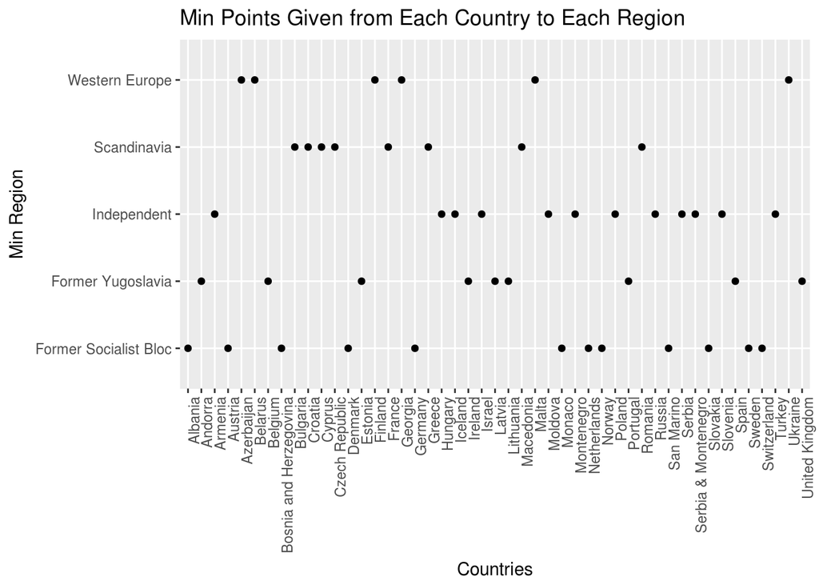

```r
euro_reg_min %>%
  ggplot(aes(x=Countries,y=`Min Region`)) +
  geom_point() +
  theme(axis.text.x = element_text(angle=90, hjust=1)) +
  labs(title = "Min Points Given from Each Country to Each Region")
```

## Conclusion

The Eurovision contest is always a lot of fun to watch and it is nice to hear and watch all of the performances from each of the countries. I was always interested to see if all the votes that came in where all based on the performance, or if politics somehow found their way into a friendly competition.

After completing this data analysis, we were able to see that there are some countries that vote soley for certain countries every year. I was not expecting to see any perfect scores on the averages so it was very surprising to see that there were in fact some countries that did only vote for certain countries, without taking into account how good of a performance it was.

Another thing that was kind of surprising was that it was verey common to see that a lot of the countries voted for the same regions that they are from. I did not expect to see that.

After completing this data anylysis, you can realize that not all of the votes are based on the artists talent and song choice.

Of course, this is not the only thing that you can learn from this dataset so I encourage you to dig deeper into the data set and see what else you can learn from the set!

Have fun!

### References

- Data Wrangling with dplyr and tidyr cheatsheet https://www.rstudio.com/wp-content/uploads/2015/02/data-wrangling-cheatsheet.pdf
- Eurovision Dataset https://docs.google.com/spreadsheets/d/1vW06CKRtgUFzZ4WZEzh_OZEycuhMvUCCxJ6MtXmeBg4/edit?hl=en&hl=en#gid=3
- dplyr library https://www.r-project.org/nosvn/pandoc/dplyr.html
- Tidy data https://www.lynda.com/R-tutorials/What-tidy-data/594442/645365-4.html
- Aggregate https://www.rdocumentation.org/packages/stats/versions/3.5.0/topics/aggregate
- ggplot https://tutorials.iq.harvard.edu/R/Rgraphics/Rgraphics.html
- ggplot cheatsheet https://www.rstudio.com/wp-content/uploads/2015/03/ggplot2-cheatsheet.pdf